# p8105_hw3_sy3270

2024-10-08

## Problem 1

## A significant portion of the dataset contains missing data, particularly in the temperature and snowfall columns.

```r
summarize(ny_noaa, across(c(tmax, tmin, prcp, snow, snwd), ~mean(is.na(.))))
```

```
## # A tibble: 1 × 5
##    tmax  tmin   prcp  snow  snwd
##   <dbl> <dbl>  <dbl> <dbl> <dbl>
## 1 0.437 0.437 0.0562 0.147 0.228
```

## Data cleaning & # Count snowfall and arrange by descending order

```r
ny_noaa_clean <- ny_noaa %>%
  separate(date, into = c("year", "month", "day"), sep = "-") %>%
  mutate(
    year = as.integer(year),
    month = as.integer(month),
    day = as.integer(day),
    tmax = as.numeric(tmax) / 10,
    tmin = as.numeric(tmin) / 10,
    prcp = as.numeric(prcp) / 10,
    snow = as.numeric(snow),
    snwd = as.numeric(snwd)
  ) %>%
  filter(!is.na(tmax) & !is.na(tmin))

ny_noaa_clean %>%
  count(snow) %>%
  arrange(desc(n)) %>%
  head(10)
```

```
## # A tibble: 10 × 2
##     snow       n
##    <dbl>   <int>
##  1     0 1167149
##  2    NA  172332
##  3    25   17542
##  4    13   13704
##  5    51   10352
##  6     5    5960
##  7    76    5894
##  8     8    5777
##  9     3    5614
## 10    38    5578
```

# Filter for January and July, group by station, year, and month to calculate average max temperature andreate a two-panel plot

```r
ny_noaa_jan_jul <- ny_noaa_clean %>%
  filter(month %in% c(1, 7)) %>%  # Filter for January and July
  group_by(id, year, month) %>%    # Group by station (id), year, and month
  summarize(mean_tmax = mean(tmax, na.rm = TRUE))  # Calculate mean max temp
```

[figure not shown]

```r
ggplot(ny_noaa_jan_jul, aes(x = year, y = mean_tmax, color = as.factor(id))) +
  geom_line() +
  facet_wrap(~month, ncol = 2) +
  labs(
    title = "Average Maximum Temperature in January and July Across Years",
    x = "Year",
    y = "Average Max Temperature (°C)",
    color = "Station ID"
  ) +
  theme_minimal()
```

# Panel 1: Plot of tmax vs tmin # Panel 2: Snowfall distribution for values greater than 0 and less than 100

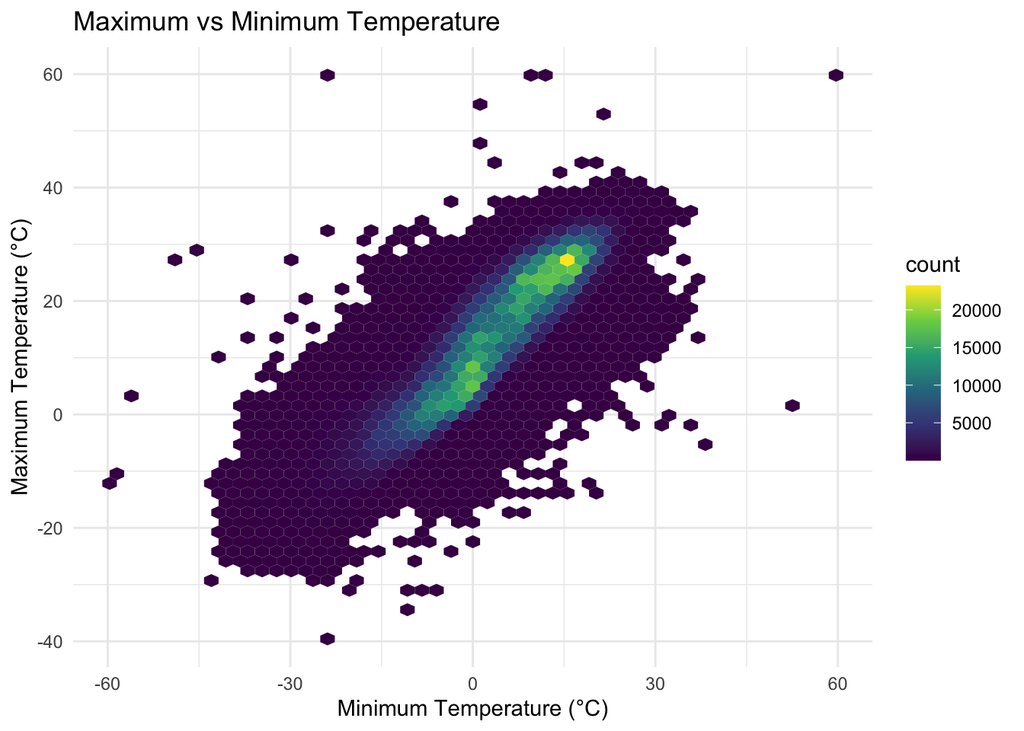

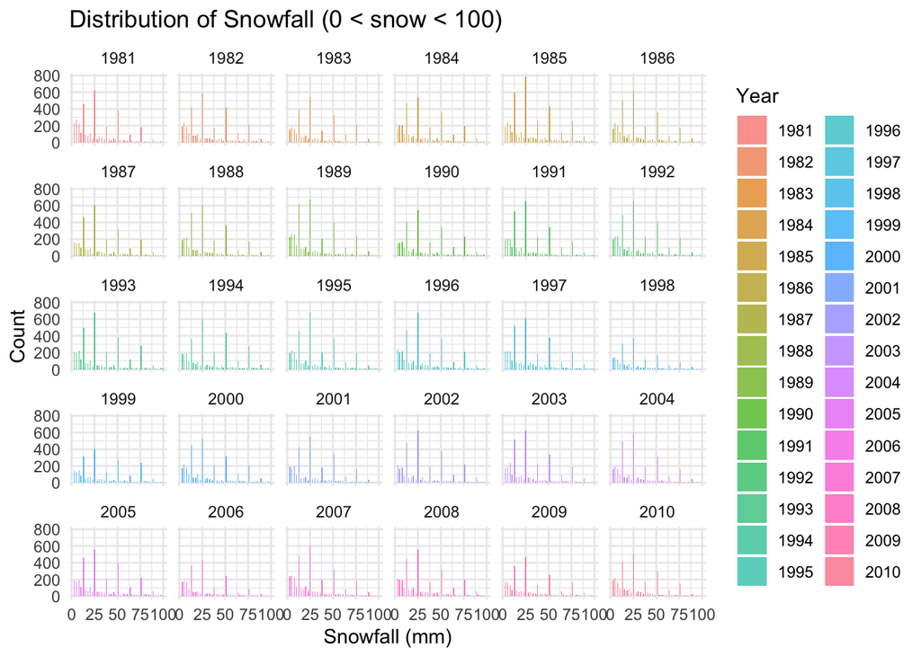

## The NYC NOAA dataset reveals clear seasonal trends in weather data, particularly in temperature and snowfall patterns. The analysis shows that January is consistently colder than July, with temperatures varying across stations and years. Snowfall is infrequent, with the majority of observations reporting no snow, and when snow does occur, it tends to be in small amounts. The scatterplot of maximum vs. minimum temperatures confirms a strong positive correlation, reflecting the overall temperature patterns. These insights demonstrate the expected seasonal and weather variability in New York City, with occasional extreme weather events reflected in the outliers.

## problem 2

#load data & inspect data

```r
nhanes_covar <- read_csv("./nhanes_covar.csv")
```

```
## ──────────────────────────────────────────────────────── Delimiter: "," chr
## (5): ...1, 1 = male, ...3, ...4, 1 = Less than high school
```

```r
nhanes_accel <- read_csv("./nhanes_accel.csv")
str(nhanes_covar)
```

```
## spc_tbl_ [254 × 5] (S3: spec_tbl_df/tbl_df/tbl/data.frame)
##  $ ...1                     : chr [1:254] NA NA NA "SEQN" ...
##  $ 1 = male                 : chr [1:254] "2 = female" NA NA "sex" ...
##  $ ...3                     : chr [1:254] NA NA NA "age" ...
##  $ ...4                     : chr [1:254] NA NA NA "BMI" ...
##  $ 1 = Less than high school: chr [1:254] "2 =  High school equivalent" "3  = More than high school" NA "education" ...
##  - attr(*, "spec")=
##   .. cols(
##   ..   ...1 = col_character(),
##   ..   `1 = male` = col_character(),
##   ..   ...3 = col_character(),
##   ..   ...4 = col_character(),
##   ..   `1 = Less than high school` = col_character()
##   .. )
##  - attr(*, "problems")=<externalptr>
```

```r
str(nhanes_accel)
```

[output not shown]

[output cut: 1491 more lines]

[output not shown]

# Data cleaning and merging, Filter participants 21+ years and remove those with missing demographic data, and Merge accelerometer data with demographic data

```r
nhanes_covar <- read_csv("./nhanes_covar.csv", skip = 4)
colnames(nhanes_covar)
```

```
## [1] "SEQN"      "sex"       "age"       "BMI"       "education"
```

```r
head(nhanes_covar)
```

```
## # A tibble: 6 × 5
##    SEQN   sex   age   BMI education
##   <dbl> <dbl> <dbl> <dbl>     <dbl>
## 1 62161     1    22  23.3         2
## 2 62164     2    44  23.2         3
## 3 62169     1    21  20.1         2
## 4 62174     1    80  33.9         3
## 5 62177     1    51  20.1         2
## 6 62178     1    80  28.5         2
```

```r
nhanes_covar_clean <- nhanes_covar %>%
  filter(age >= 21) %>%
  drop_na()

nhanes_covar_clean <- nhanes_covar_clean %>%
  mutate(
    sex = factor(sex, levels = c("1", "2"), labels = c("Male", "Female")),
    education = factor(education, levels = c("1", "2", "3", "4"),
                       labels = c("Less than high school", "High school", "Some college", "College degree"))
  )

nhanes_data <- nhanes_accel %>%
  left_join(nhanes_covar_clean, by = "SEQN")
```

# Number of Men and Women by Education Category

```r
table_men_women_edu <- nhanes_covar_clean %>%
  group_by(education, sex) %>%
  summarize(n = n()) %>%
  pivot_wider(names_from = sex, values_from = n, values_fill = 0)
table_men_women_edu
```

```
## # A tibble: 3 × 3
## # Groups:   education [3]
##   education              Male Female
##   <fct>                 <int>  <int>
## 1 Less than high school    27     28
## 2 High school              35     23
## 3 Some college             56     59
```

# Age Distribution by Sex and Education Category & Create a plot showing the age distribution by sex and education

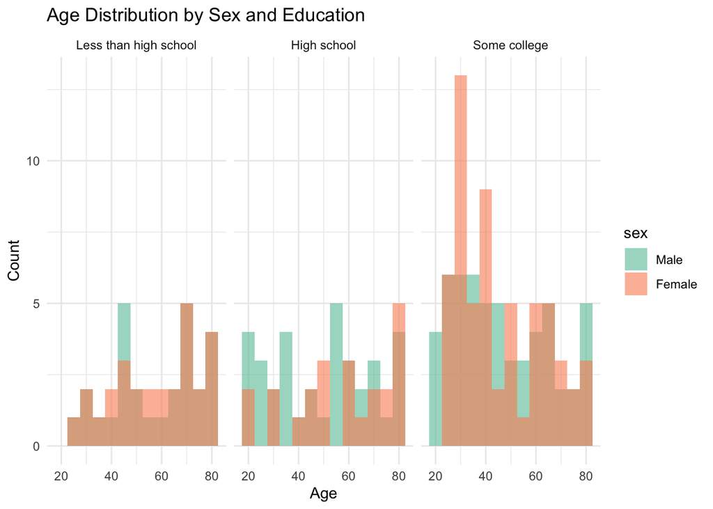

# Total Activity vs Age, by Sex and Education Level

[output not shown]

[output cut: 191 more lines]

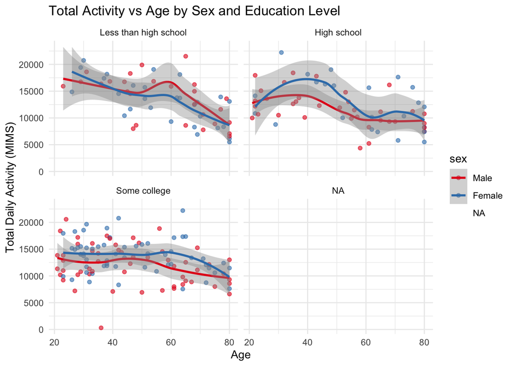